# Exploring with R - Natural Resources

G.Tsolov

2022-03-29

# Source

https://ourworldindata.org/fossil-fuels  
further sources cited within each dataset.

## Environment setup

Loading and preparing the usual.

```r
install.packages("tidyverse")
library(tidyverse)
```

```r
library(dplyr)
library(tidyr)
library(readr)
library(ggplot2)
install.packages("corrplot")
library(corrplot)
install.packages("here")
library(here)
install.packages("skimr")
library(skimr)
install.packages("janitor")
library(janitor)
```

## Loading and viewing the data

```r
resources_final <- readRDS("resources_final.RDS")

str(resources_final)
```

```
## spec_tbl_df [8,972 × 23] (S3: spec_tbl_df/tbl_df/tbl/data.frame)
##  $ ...1               : num [1:8972] 1 2 3 4 5 6 7 8 9 10 ...
##  $ record_id          : num [1:8972] 1 2 3 4 5 6 7 8 9 10 ...
##  $ Country            : chr [1:8972] "Afghanistan" "Afghanistan" "Afghanistan" "Afghanistan" ...
##  $ Population         : num [1:8972] 13360000 13170000 12880000 12540000 12200000 ...
##  $ Year               : num [1:8972] 1980 1981 1982 1983 1984 ...
##  $ gas_production     : num [1:8972] 1.70e+09 2.24e+09 2.29e+09 2.41e+09 2.41e+09 ...
##  $ gas_consumption    : num [1:8972] 5.66e+07 8.50e+07 1.42e+08 1.42e+08 1.42e+08 ...
##  $ gas_exports        : num [1:8972] 0 0 0 0 0 0 0 0 0 0 ...
##  $ coal_production    : num [1:8972] 119000 125000 145000 145000 148000 151000 160000 167000 138000 127000 ...
##  $ coal_consumption   : num [1:8972] 119000 125000 145000 145000 148000 151000 160000 167000 138000 127000 ...
##  $ coal_exports       : num [1:8972] 0 0 0 0 0 0 0 0 0 0 ...
##  $ oil_production     : num [1:8972] 0 0 0 0 0 0 0 0 0 0 ...
##  $ oil_consumption    : num [1:8972] 406500 464600 452900 638800 638800 ...
##  $ oil_exports        : num [1:8972] 0 0 0 0 0 0 0 0 0 0 ...
##  $ gas_production_pc  : num [1:8972] 127 170 178 192 197 ...
##  $ gas_consumption_pc : num [1:8972] 4.24 6.45 10.99 11.29 11.6 ...
##  $ gas_exports_pc     : num [1:8972] 0 0 0 0 0 0 0 0 0 0 ...
##  $ coal_production_pc : num [1:8972] 0.00891 0.00949 0.01126 0.01157 0.01213 ...
##  $ coal_consumption_pc: num [1:8972] 0.00891 0.00949 0.01126 0.01157 0.01213 ...
##  $ coal_exports_pc    : num [1:8972] 0 0 0 0 0 0 0 0 0 0 ...
##  $ oil_production_pc  : num [1:8972] 0 0 0 0 0 0 0 0 0 0 ...
##  $ oil_consumption_pc : num [1:8972] 0.0304 0.0353 0.0352 0.051 0.0523 ...
##  $ oil_exports_pc     : num [1:8972] 0 0 0 0 0 0 0 0 0 0 ...
##  - attr(*, "spec")=
##   .. cols(
##   ..   ...1 = col_double(),
##   ..   record_id = col_double(),
##   ..   Country = col_character(),
##   ..   Population = col_double(),
##   ..   Year = col_double(),
##   ..   gas_production = col_double(),
##   ..   gas_consumption = col_double(),
##   ..   gas_exports = col_double(),
##   ..   coal_production = col_double(),
##   ..   coal_consumption = col_double(),
##   ..   coal_exports = col_double(),
##   ..   oil_production = col_double(),
##   ..   oil_consumption = col_double(),
##   ..   oil_exports = col_double(),
##   ..   gas_production_pc = col_double(),
##   ..   gas_consumption_pc = col_double(),
##   ..   gas_exports_pc = col_double(),
##   ..   coal_production_pc = col_double(),
##   ..   coal_consumption_pc = col_double(),
##   ..   coal_exports_pc = col_double(),
##   ..   oil_production_pc = col_double(),
##   ..   oil_consumption_pc = col_double(),
##   ..   oil_exports_pc = col_double()
##   .. )
##  - attr(*, "problems")=<externalptr>
```

Seems like the first three gas columns in **View** and **str** can’t fit the data. Tried changing the data type when loading. Originally as double, change to integer or numeric - no success. Values are readable when viewed with **head**.

Need to check if the actual values are being read. Let’s see how much is the total gas production:

```r
sum(resources_final$gas_production, na.rm=TRUE)
```

```
## [1] 1.048017e+14
```

It seems it’s performing calculations but the result is not readable.  
Will try and scale down the numbers by creating a calculated field dividing by 1 000 000. Removing 6 zeroes might do the trick:

```r
test_new_field <- resources_final %>%
  mutate(new_gas_prod = gas_production / 1000000)

sum(test_new_field$new_gas_prod, na.rm = TRUE)
```

```
## [1] 104801685
```

Result is now readable. Must keep track of this and name fields accordingly!!!  
Reproduce for all three gas columns:

```r
resources_1 <- resources_final %>%
  mutate(gas_production_mill = gas_production / 1000000) %>%
  mutate(gas_consumption_mill = gas_consumption / 1000000) %>%
  mutate(gas_exports_mill = gas_exports / 1000000)
```

Tested summing up all new columns. Results are readable. Creating the final work table while excluding the original fields:

```r
work_df <- resources_1 %>%
  select(-gas_production, -gas_consumption, -gas_exports)

glimpse(work_df)
```

```
## Rows: 8,972
## Columns: 23
## $ ...1                 <dbl> 1, 2, 3, 4, 5, 6, 7, 8, 9, 10, 11, 12, 13, 14, 15…
## $ record_id            <dbl> 1, 2, 3, 4, 5, 6, 7, 8, 9, 10, 11, 12, 13, 14, 15…
## $ Country              <chr> "Afghanistan", "Afghanistan", "Afghanistan", "Afg…
## $ Population           <dbl> 13360000, 13170000, 12880000, 12540000, 12200000,…
## $ Year                 <dbl> 1980, 1981, 1982, 1983, 1984, 1985, 1986, 1987, 1…
## $ coal_production      <dbl> 119000, 125000, 145000, 145000, 148000, 151000, 1…
## $ coal_consumption     <dbl> 119000, 125000, 145000, 145000, 148000, 151000, 1…
## $ coal_exports         <dbl> 0, 0, 0, 0, 0, 0, 0, 0, 0, 0, 0, 0, 0, 0, 0, 0, 0…
## $ oil_production       <dbl> 0, 0, 0, 0, 0, 0, 0, 0, 0, 0, 0, 0, 0, 0, 0, 0, 0…
## $ oil_consumption      <dbl> 406500, 464600, 452900, 638800, 638800, 754900, 7…
## $ oil_exports          <dbl> 0, 0, 0, 0, 0, 0, 0, 0, 0, 0, 0, 0, 0, 0, 0, 0, 1…
## $ gas_production_pc    <dbl> 127.20, 169.90, 178.10, 192.00, 197.20, 249.10, 2…
## $ gas_consumption_pc   <dbl> 4.24, 6.45, 10.99, 11.29, 11.60, 0.00, 0.00, 53.6…
## $ gas_exports_pc       <dbl> 0.00, 0.00, 0.00, 0.00, 0.00, 0.00, 0.00, 0.00, 0…
## $ coal_production_pc   <dbl> 0.008910, 0.009490, 0.011260, 0.011570, 0.012130,…
## $ coal_consumption_pc  <dbl> 0.008910, 0.009490, 0.011260, 0.011570, 0.012130,…
## $ coal_exports_pc      <dbl> 0, 0, 0, 0, 0, 0, 0, 0, 0, 0, 0, 0, 0, 0, 0, 0, 0…
## $ oil_production_pc    <dbl> 0, 0, 0, 0, 0, 0, 0, 0, 0, 0, 0, 0, 0, 0, 0, 0, 0…
## $ oil_consumption_pc   <dbl> 0.030430, 0.035270, 0.035160, 0.050950, 0.052340,…
## $ oil_exports_pc       <dbl> 0.000000, 0.000000, 0.000000, 0.000000, 0.000000,…
## $ gas_production_mill  <dbl> 1699.00, 2237.00, 2294.00, 2407.00, 2407.00, 2974…
## $ gas_consumption_mill <dbl> 56.64, 84.96, 141.60, 141.60, 141.60, 0.00, 0.00,…
## $ gas_exports_mill     <dbl> 0, 0, 0, 0, 0, 0, 0, 0, 0, 0, 1025, 0, 0, 0, 0, 0…
```

- Hours later… After much trouble with readability (also in visualizations) I decided to divide all relevant fields by 1 million. Note to self - always scale down your values to avoid such complications. I think that’s also the right way to keep data (thousands/millions in field name, not piling on mad zeroes).

```r
work_df_1 <- work_df %>%
  mutate(coal_production_mill = coal_production / 1000000) %>%
  mutate(coal_consumption_mill = coal_consumption / 1000000) %>%
  mutate(coal_exports_mill = coal_exports / 1000000) %>%
  mutate(oil_production_mill = oil_production / 1000000) %>%
  mutate(oil_consumption_mill = oil_consumption / 1000000) %>%
  mutate(oil_exports_mill = oil_exports / 1000000)
```

- New work df (hopefully final)

```r
work_df_final <- work_df_1 %>%
  select(-coal_production, -coal_consumption, -coal_exports, -oil_production, -oil_consumption, -oil_exports)

glimpse(work_df_final)
```

### Trying out a matrix plot:

```r
test_corr <- work_df_final %>%
  select(-Country, -record_id)

corr_main <- cor(test_corr)

round(corr_main, digits = 2)
```

- Visualizing correlation matrix:

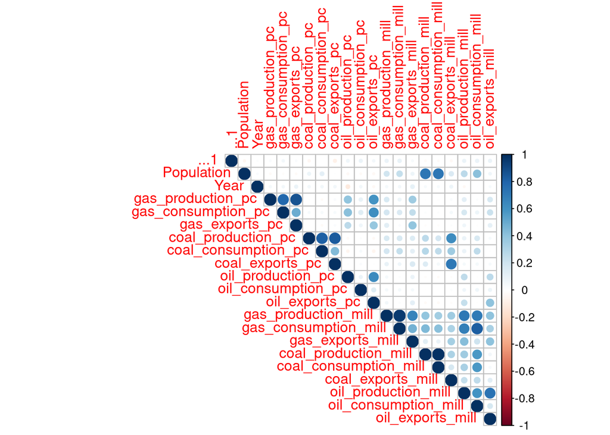

```r
corrplot(corr_main, type = "upper")
```

- Reordering correlation matrix:

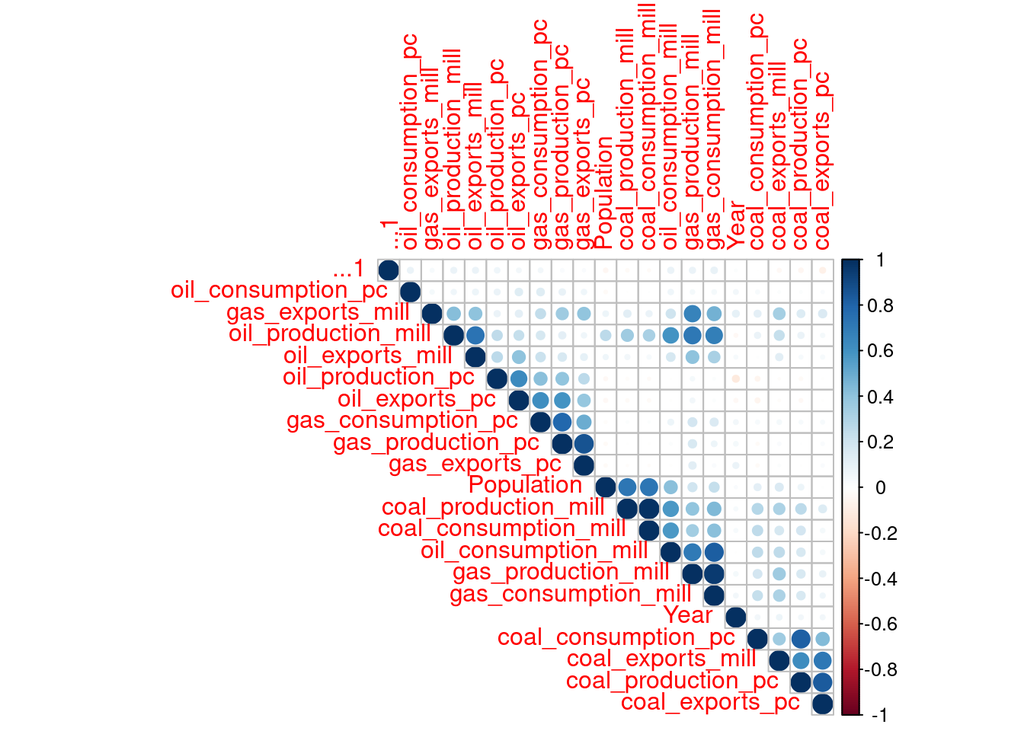

```r
corrplot(corr_main, type = "upper", order = "hclust")
```

I know this dataframe is not the best for testing correlation but I wanted to try it out. Result - a few interesting relationships to investigate and no inverse relationships.

## Back on it

As most correlations are obvious - like production to exports, and production to consumption - there are a few interesting ones which I will preview in a bit. Obviously, some of the biggest producers of fossil fuels in the world are also one of the biggest consumers and exporters.

### Basic info first

10 year period - 2011 to 2020!!! TOP 10 countries.

- COAL - biggest producers

```r
coal_prod_summary <- work_df_final %>%
  select(Country, Year, coal_production_mill) %>%
  filter(Year >= 2011, Year <= 2020) %>%
  group_by(Country) %>%
  summarize(total_period = sum(coal_production_mill))

coal_prod_top10 <- coal_prod_summary %>%
  arrange(-total_period) %>%
  top_n(10)
```

- COAL - biggest consumers

```r
coal_consump_summary <- work_df_final %>%
  select(Country, Year, coal_consumption_mill) %>%
  filter(Year >= 2011, Year <= 2020) %>%
  group_by(Country) %>%
  summarize(total_period = sum(coal_consumption_mill))

coal_consump_top10 <- coal_consump_summary %>%
  arrange(-total_period) %>%
  top_n(10)
```

- COAL - biggest exporters

```r
coal_exports_summary <- work_df_final %>%
  select(Country, Year, coal_exports_mill) %>%
  filter(Year >= 2011, Year <= 2020) %>%
  group_by(Country) %>%
  summarize(total_period = sum(coal_exports_mill))

coal_exports_top10 <- coal_exports_summary %>%
  arrange(-total_period) %>%
  top_n(10)
```

- A visual for Coal:

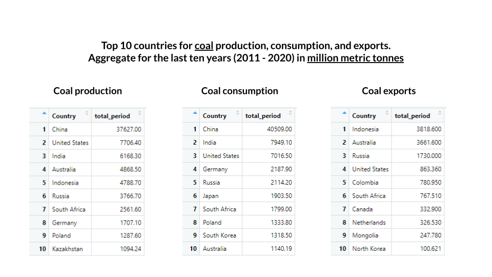

- GAS - repeat everything.

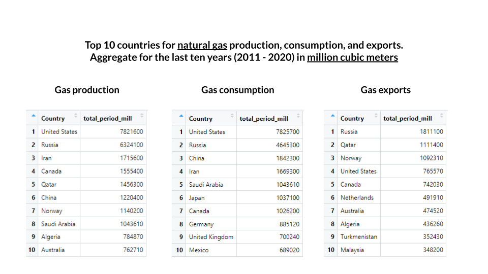

- Oil - repeat again.

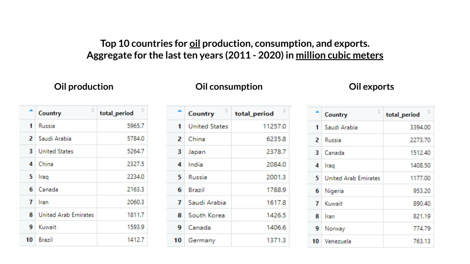

### Interesting correlations

In order to keep things cleaner I will focus on some of the countries from the top_10 results above.

- Gas production to Oil production

```r
new_a1 <- work_df_final %>%
  filter(Year >= 2011, Year <= 2020) %>%
  filter(Country %in% c("United States", "Norway", "Iran", "China", "Iraq", "Canada", "Saudi Arabia", "Kuwait", "Brazil", "Qatar", "Russia", "Algeria"))
```

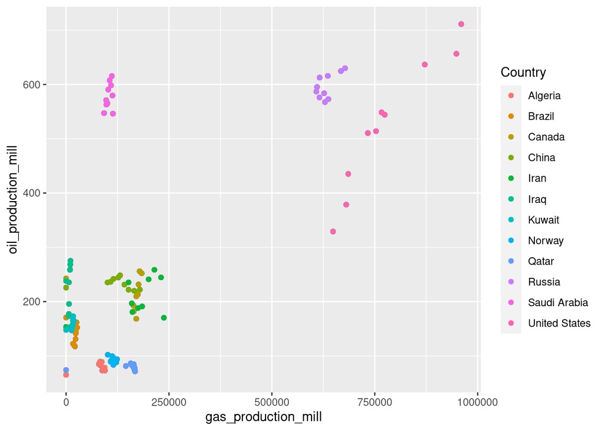

```r
ggplot(new_a1, aes(gas_production_mill, oil_production_mill)) +
  geom_jitter(aes(group = Country)) +
  geom_point(aes(colour = Country))
```

- Change in gas production.  
  China, Iraq, Iran, and Brazil have achieved significant increase in gas production. Followed closely by Kuwait and the US. Notable here is Russia with practically no change.

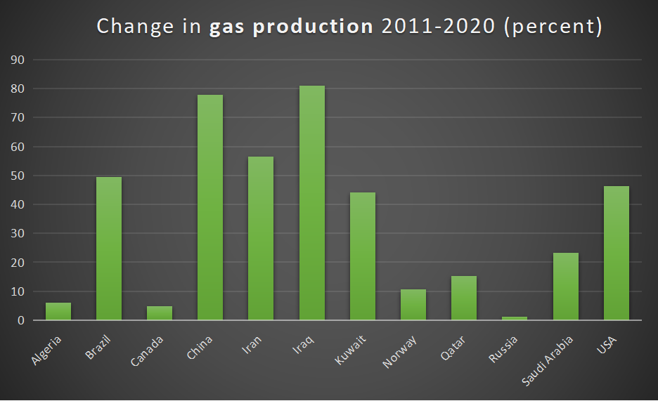

- Change in oil production.  
  The US have doubled their oil production over the past ten years surpassing even Russia and Saudi Arabia. This now grants them the number one spot in the world. Other countries to note are Iraq, Canada, and Brazil, who also see a significant increase. Russia and Saudi Arabia, as former leaders in oil production see little-to-no change in their production.

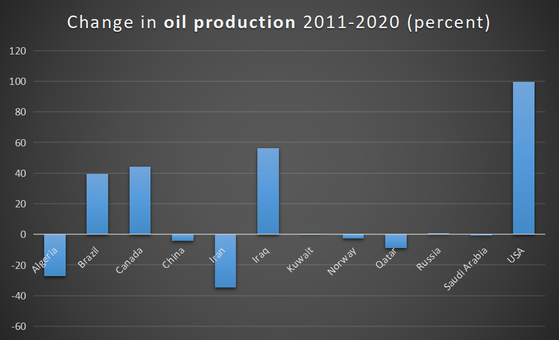

- Coal production & consumption compared to Population

```r
new_a2 <- work_df_final %>%
  select(Country, Year, Population, coal_production_mill, coal_consumption_mill) %>%
  filter(Year >= 2011, Year <= 2020) %>%
  filter(Country %in% c("United States", "Australia", "Germany", "Russia", "Indonesia", "South Africa", "Poland"))
```

I’m excluding China and India here for a better visualization later.

Again having trouble with readability on visualizations.

Tried adding a calculated field but it reads the data as string, despite the fact that Population data type is listed as double… Exporting a few filtered tables to spreadsheets so I can divide Population by 1 mill.

Added new field and imported table. Let’s try this again:

```r
install.packages("readxl")
library(readxl)

new_a3 <- read_xlsx("new_a3.xlsx")
str(new_a3)
```

```
## tibble [80 × 6] (S3: tbl_df/tbl/data.frame)
##  $ Country              : chr [1:80] "Australia" "Australia" "Australia" "Australia" ...
##  $ Year                 : num [1:80] 2011 2012 2013 2014 2015 ...
##  $ Population           : num [1:80] 22540000 22900000 23250000 23600000 23930000 ...
##  $ coal_production_mill : num [1:80] 421 441 468 498 521 ...
##  $ coal_consumption_mill: num [1:80] 129 128 117 112 117 ...
##  $ pop_mill             : num [1:80] 22.5 22.9 23.2 23.6 23.9 ...
```

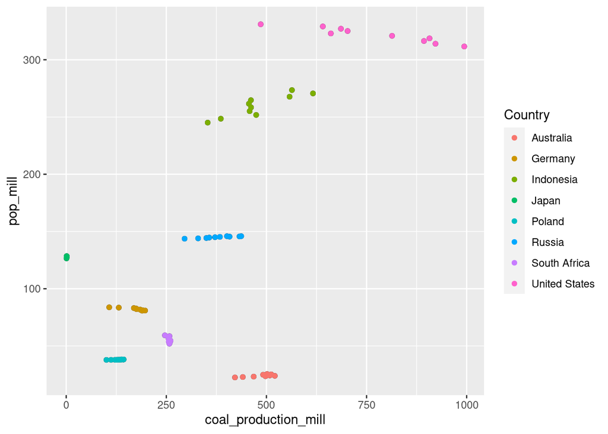

```r
ggplot(new_a3, aes(coal_production_mill, pop_mill)) +
  geom_jitter(aes(group = Country)) +
  geom_point(aes(colour = Country))
```

Interesting here is Australia with it’s small population but very high coal production. They must have one of the highest coal production per capita - let’s check:

```r
a3_pc_top <- work_df_final %>%
  select(Country, Year, coal_production_pc) %>%
  filter(Year >= 2011, Year <= 2020) %>%
  group_by(Country) %>%
  summarize(avg_coal_pc = mean(coal_production_pc)) %>%
  arrange(-avg_coal_pc) %>%
  top_n(10)
head(a3_pc_top)
```

| Country | avg_coal_pc |
| --- | --- |
| Australia | 20.2200 |
| Mongolia | 12.3234 |
| Kazakhstan | 6.2187 |
| South Africa | 4.6059 |
| Czechia | 4.3534 |
| Bulgaria | 4.3506 |

We can confirm it. Australia has BY FAR the largest per capita production of coal in the world. Otherwise the biggest producer of coal by sheer volume is undisputedly China.

- Now let’s see consumption (including China & India):

```r
new_a4 <- work_df_final %>%
  select(Country, Year, Population, coal_production_mill, coal_consumption_mill) %>%
  filter(Year >= 2011, Year <= 2020) %>%
  filter(Country %in% c("United States", "Australia", "Germany", "Russia", "Indonesia", "South Africa", "Poland", "China", "India"))
```

Again had to export to spreadsheets for the calculation. Note to self - I should really make a better plan at the start…

```r
new_a5 <- read_xlsx("new_a4.xlsx")
str(new_a5)
```

```
## tibble [90 × 6] (S3: tbl_df/tbl/data.frame)
##  $ Country              : chr [1:90] "Australia" "Australia" "Australia" "Australia" ...
##  $ Year                 : num [1:90] 2011 2012 2013 2014 2015 ...
##  $ Population           : num [1:90] 22540000 22900000 23250000 23600000 23930000 ...
##  $ coal_production_mill : num [1:90] 421 441 468 498 521 ...
##  $ coal_consumption_mill: num [1:90] 129 128 117 112 117 ...
##  $ pop_mill             : num [1:90] 22.5 22.9 23.2 23.6 23.9 ...
```

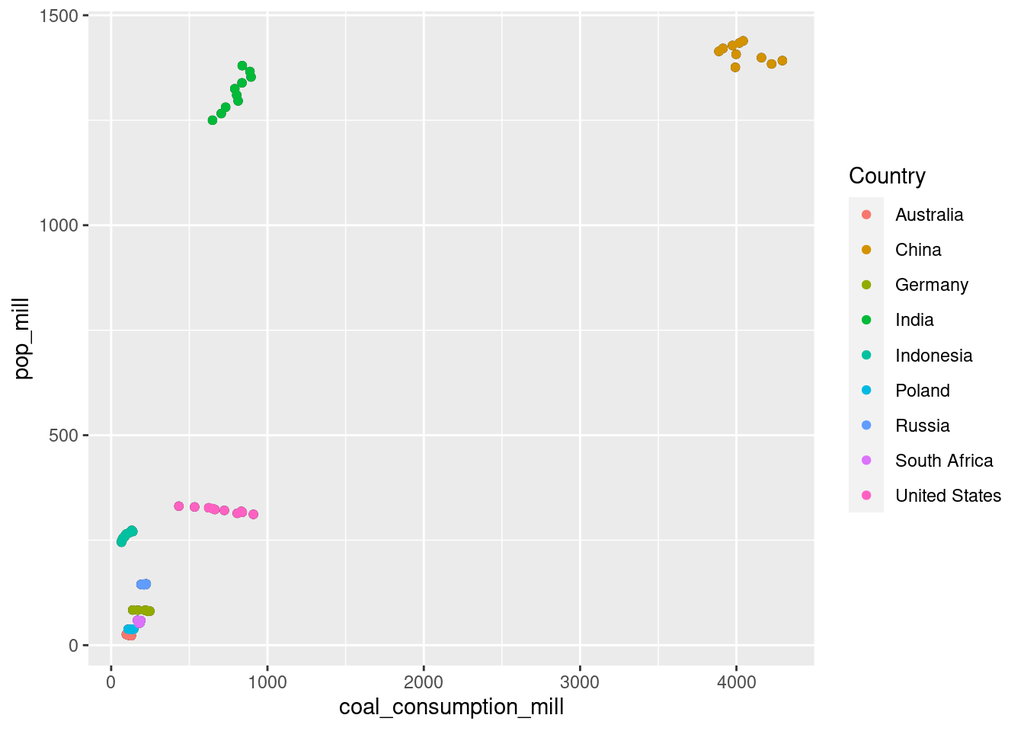

```r
ggplot(new_a5, aes(coal_consumption_mill, pop_mill)) +
  geom_jitter(aes(group = Country)) +
  geom_point(aes(colour = Country))
```

- Finally let’s see countries with the highest consumption per capita:

```r
a5_pc_top <- work_df_final %>%
  select(Country, Year, coal_consumption_pc) %>%
  filter(Year >= 2011, Year <= 2020) %>%
  group_by(Country) %>%
  summarize(avg_coal_pc = mean(coal_consumption_pc)) %>%
  arrange(-avg_coal_pc) %>%
  top_n(10)
head(a5_pc_top)
```

| Country | avg_coal_pc |
| --- | --- |
| Australia | 4.7594 |
| Kazakhstan | 4.5352 |
| Bulgaria | 4.5342 |
| Serbia | 4.3852 |
| Czechia | 4.2726 |
| Greece | 3.9920 |